# NBA Game Outcome Prediction Project

1. Introduction
2. Primary Goals
3. Models Employed
4. Data Source and Citation
5. Importing & Cleaning Data
6. Handling Missing Values
7. Exploratory Data Analysis (EDA)
8. Train-Test Split
9. Preprocessing and Pipelines
10. K-Fold Cross-Validation
11. Hyperparameter Tuning Using Grid Search
12. Model Training
13. Model Result Summaries
14. Model Performance Analysis
15. Gradient Boosting Performance Metrics
16. Conclusion

## 1. Introduction

For my project, I wanted to analyze NBA game data to build predictive models that can determine game outcomes based on in-game statistics. The dataset I'm using provides detailed "snapshots" of games at regular time intervals, tracking the score, time remaining, and other metrics throughout each game.

As a basketball fan, I've always been fascinated by the concept of win probability and how it fluctuates during games. Commentators often discuss how certain moments are "turning points" in games, but I wanted to explore this analytically. My goal is to determine how accurately we can predict the final outcome of an NBA game based on the state of the game at various time points, and to identify which factors are most important in making these predictions.

## 2. Primary Goals

1. Build machine learning models that can accurately predict which team will win an NBA game based on in-game statistics like score differential, time remaining, period, and other features in my dataset.
2. Analyze how win probability evolves throughout games and determine at what point in games predictions become reliable.
3. Compare the performance of different machine learning approaches (logistic regression, random forests, gradient boosting, etc) to see which works best for this prediction task.
4. Identify key moments or thresholds during games that have the strongest correlation with final outcomes, essentially finding the statistical "point of no return" in NBA games.

I believe this analysis will provide interesting insights into basketball game dynamics and potentially reveal patterns that aren't obvious to casual observers of the game.

[figure not shown]

## 3. Models Employed

1. Logistic Regression
2. Random Forest
3. Gradient Boost
4. Support Vector Machine

## 4. Data Source and Citation

For my project, I collected NBA game data using the nba_api Python package, which provides direct accest to NBA.com's official statistics. I collected the raw data the dataset I'm using was configured to contain a season's worth of NBA game snapshots with numerous features (reference codebook.md)

### Formal Citation:

Swar, S. (2018). nba_api: An API Client package to access NBA.com endpoints. Available from https://github.com/swar/nba_api Link to Source: https://github.com/swar/nba_api

## 5. Importing & Cleaning Data

```python
import pandas as pd

games_2022_2023 = pd.read_csv("../../data/revised_nba_2022_23_all_games_snapshots.csv")
for column in games_2022_2023.columns:
    print(f"Column {column} has {games_2022_2023[column].isna().sum()} missing values")

overtime_games = games_2022_2023[games_2022_2023['PERIOD'] == 5]['GAME_ID'].unique()
df_filtered = games_2022_2023[~games_2022_2023['GAME_ID'].isin(overtime_games)]

print(f"Original dataset size: {len(games_2022_2023)}")
print(f"Number of overtime games removed: {len(overtime_games)}")
print(f"Filtered dataset size: {len(df_filtered)}")

for column in df_filtered.columns:
    print(f"Column {column} has {df_filtered[column].isna().sum()} missing values")


df_filtered = df_filtered.sort_values(['GAME_ID', 'seconds_elapsed'])
df_filtered['MOMENTUM'] = df_filtered.groupby('GAME_ID')['SCORE_DIFF'].diff(periods=4)
df_filtered['MOMENTUM'] = df_filtered['MOMENTUM'].fillna(0)
df_filtered.to_csv("../../data/new_nba_2022_23_all_games_snapshots.csv", index=False)
```

```
Column seconds_elapsed has 0 missing values
Column GAME_ID has 0 missing values
Column PERIOD has 0 missing values
Column AWAY_SCORE has 1792 missing values
Column HOME_SCORE has 1792 missing values
Column SCORE_DIFF has 1792 missing values
Column IS_HOME_LEADING has 1792 missing values
Column HOME_TEAM_WIN_PCT has 1792 missing values
Column AWAY_TEAM_WIN_PCT has 1792 missing values
Column HOME_TEAM_WON has 1792 missing values
Column HOME_TEAM has 1792 missing values
Column AWAY_TEAM has 1792 missing values
Column PCTIMESTRING has 0 missing values
Original dataset size: 174200
Number of overtime games removed: 79
Filtered dataset size: 159500
Column seconds_elapsed has 0 missing values
Column GAME_ID has 0 missing values
Column PERIOD has 0 missing values
Column AWAY_SCORE has 0 missing values
Column HOME_SCORE has 0 missing values
Column SCORE_DIFF has 0 missing values
Column IS_HOME_LEADING has 0 missing values
Column HOME_TEAM_WIN_PCT has 0 missing values
Column AWAY_TEAM_WIN_PCT has 0 missing values
Column HOME_TEAM_WON has 0 missing values
Column HOME_TEAM has 0 missing values
Column AWAY_TEAM has 0 missing values
Column PCTIMESTRING has 0 missing values
```

### Read in the new data

```python
nba_games_2022_2023 = pd.read_csv("../../data/new_nba_2022_23_all_games_snapshots.csv")
nba_games_2022_2023.head()
```

|  | seconds_elapsed | GAME_ID | PERIOD | AWAY_SCORE | HOME_SCORE | SCORE_DIFF | IS_HOME_LEADING | HOME_TEAM_WIN_PCT | AWAY_TEAM_WIN_PCT | HOME_TEAM_WON | HOME_TEAM | AWAY_TEAM | PCTIMESTRING | MOMENTUM |
| --- | --- | --- | --- | --- | --- | --- | --- | --- | --- | --- | --- | --- | --- | --- |
| 0 | 0 | 22200001 | 1 | 0.0 | 0.0 | 0.0 | 0.0 | 1.0 | 0.0 | 1.0 | Boston Celtics | Philadelphia 76ers | 12:00 | 0.0 |
| 1 | 0 | 22200001 | 1 | 0.0 | 0.0 | 0.0 | 0.0 | 1.0 | 0.0 | 1.0 | Boston Celtics | Philadelphia 76ers | 12:00 | 0.0 |
| 2 | 30 | 22200001 | 1 | 0.0 | 0.0 | 0.0 | 0.0 | 1.0 | 0.0 | 1.0 | Boston Celtics | Philadelphia 76ers | 11:30 | 0.0 |
| 3 | 30 | 22200001 | 1 | 0.0 | 0.0 | 0.0 | 0.0 | 1.0 | 0.0 | 1.0 | Boston Celtics | Philadelphia 76ers | 11:30 | 0.0 |
| 4 | 60 | 22200001 | 1 | 2.0 | 2.0 | 0.0 | 0.0 | 1.0 | 0.0 | 1.0 | Boston Celtics | Philadelphia 76ers | 11:00 | 0.0 |

## 6. Handling Missing Values

```
Handling Missing Values in Overtime Games:
```

Upon initial exploration, I identified 1,792 missing values in my dataset's scoring-related features. Further investigation revealed a systematic pattern: these missing values occurred exclusively in overtime periods (specifically when games reached a 5th period). The missing data spans from the 12:00 to 5:30 mark (minutes and seconds remaining) or equivalently from the 0 to 390th second mark of overtime periods. This pattern exists because NBA overtime periods are only 5 minutes long, rather than the standard 12 minutes of regular quarters. Since overtime games constitute a relatively small proportion of my dataset, there aren't enough unique overtime period snapshots to enable reliable model training for these scenarios. Therefore, to maintain data consistency and model reliability, I decided to exclude all overtime games from my analysis. This approach allows me to focus on regulation-time game dynamics while eliminating the missing value issue entirely, rather than implementing imputation methods that might introduce bias into the overtime period data.

## 7. Exploratory Data Analysis

```
Correlation Matrix:
```

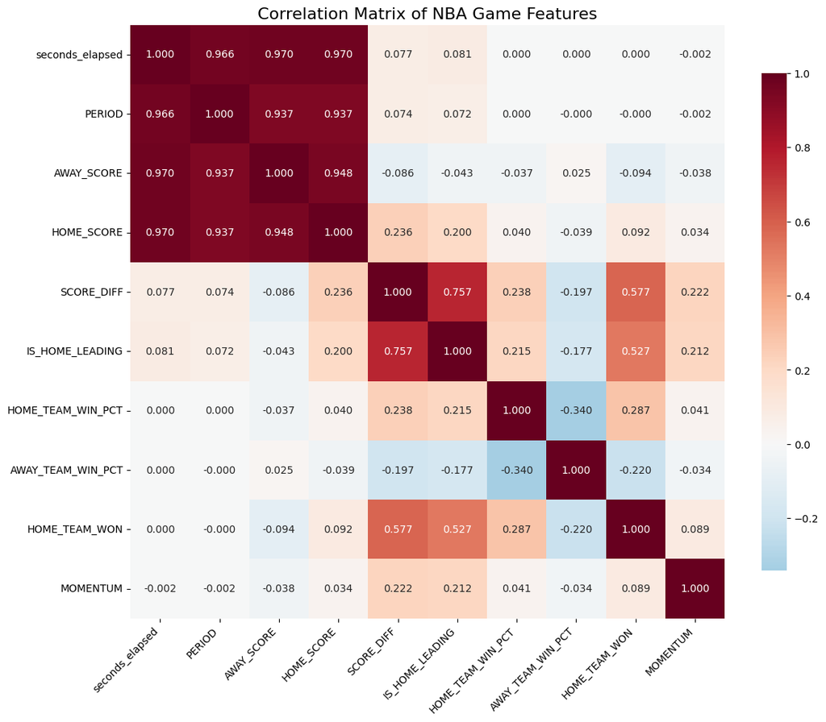

```python
import matplotlib.pyplot as plt
import seaborn as sns
import numpy as np

numeric_features = [
    'seconds_elapsed', 'PERIOD', 'AWAY_SCORE', 'HOME_SCORE',
    'SCORE_DIFF', 'IS_HOME_LEADING', 'HOME_TEAM_WIN_PCT',
    'AWAY_TEAM_WIN_PCT', 'HOME_TEAM_WON', 'MOMENTUM'
]


correlation_matrix = nba_games_2022_2023[numeric_features].corr()

plt.figure(figsize=(12, 10))
sns.heatmap(correlation_matrix,
            annot=True,
            cmap='RdBu_r',
            center=0, \
            square=True,
            fmt='.3f',
            cbar_kws={'shrink': 0.8})

plt.title('Correlation Matrix of NBA Game Features', fontsize=16)
plt.xticks(rotation=45, ha='right')
plt.yticks(rotation=0)
plt.tight_layout()
plt.show()
```

## Target Variable Predictors (HOME_TEAM_WON)

```
Strong Predictors:
```

SCORE_DIFF (0.577) - The strongest predictor, confirming that current score differential is highly indicative of final outcome IS_HOME_LEADING (0.527) - Nearly as strong, showing that simply being ahead is a powerful predictor

```
Moderate Predictors:
```

HOME_TEAM_WIN_PCT (0.287) - Team quality matters, with better home teams more likely to win AWAY_TEAM_WIN_PCT (-0.220) - Inverse relationship as expected; stronger away teams reduce home team win probability

```
Weak Predictors:
```

HOME_SCORE/AWAY_SCORE (0.092/-0.094) - Raw scores matter less than the differential MOMENTUM (0.089) - Surprisingly weak, suggesting recent scoring trends are less predictive than current game state seconds_elapsed/PERIOD (≈0.000) - Time itself has virtually no correlation with outcome

```
Critical Multicollinearity Issues
```

Severe Problems (>0.9 correlation):

Time variables: seconds_elapsed vs PERIOD (0.966) - These measure the same thing Score progression: Both scores correlate 0.97+ with time, indicating scores naturally increase as games progress Score relationship: AWAY_SCORE vs HOME_SCORE (0.948) - Games tend to have similar total scoring

```
Moderate Problem:
```

SCORE_DIFF vs IS_HOME_LEADING (0.757) - Logically connected but not perfectly correlated due to tied games

```
Distribution of Score Differentials:
```

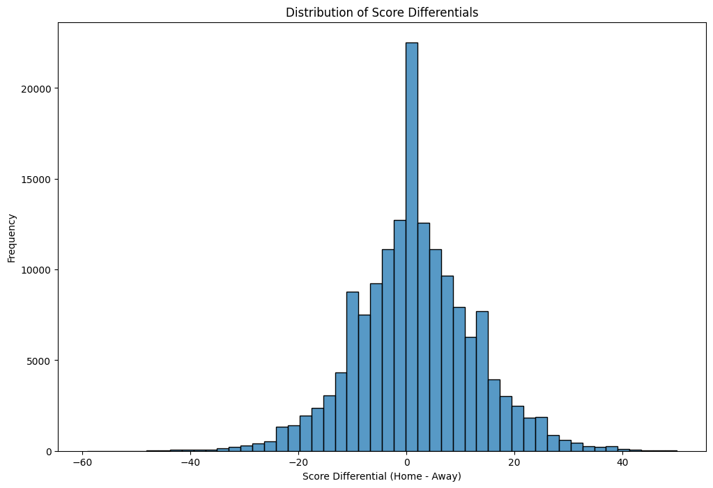

```python
plt.figure(figsize=(12, 8))
sns.histplot(data=nba_games_2022_2023, x='SCORE_DIFF', bins=50)
plt.title('Distribution of Score Differentials')
plt.xlabel('Score Differential (Home - Away)')
plt.ylabel('Frequency')
```

As one might expect the distribution of the score differentials is approximatley normal. One interesting insight I can glean from the symmetry of the normal distribution is also telling is that it means when games do get lopsided, they're just as likely to be blowouts in favor of the home team as they are for the away team. This is different from what we might expect if home court advantage was really dominant, in that case, we'd probably see the distribution skewed toward positive score differentials.

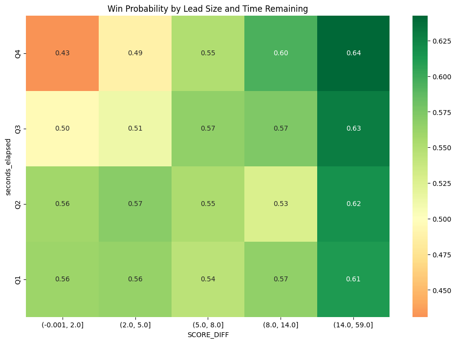

```python
time_remaining = 2880 - nba_games_2022_2023['seconds_elapsed']
time_bins = pd.qcut(time_remaining, q=4, labels=['Q4', 'Q3', 'Q2', 'Q1'])
lead_bins = pd.qcut(nba_games_2022_2023['SCORE_DIFF'].abs(), q=5)


win_prob = nba_games_2022_2023.groupby([time_bins, lead_bins])['HOME_TEAM_WON'].mean().unstack()


plt.figure(figsize=(12, 8))
sns.heatmap(win_prob, annot=True, fmt='.2f', cmap='RdYlGn', center=0.5)
plt.title('Win Probability by Lead Size and Time Remaining')
```

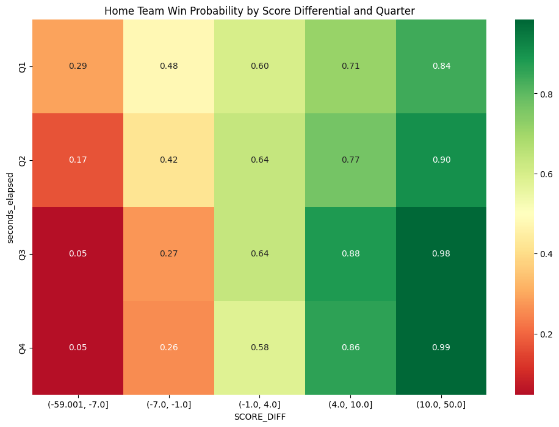

```python
time_bins = pd.qcut(nba_games_2022_2023['seconds_elapsed'], q=4, labels=['Q1', 'Q2', 'Q3', 'Q4'])
score_bins = pd.qcut(nba_games_2022_2023['SCORE_DIFF'], q=5)
win_prob = nba_games_2022_2023.groupby([time_bins, score_bins])['HOME_TEAM_WON'].mean().unstack()


plt.figure(figsize=(12, 8))
sns.heatmap(win_prob, annot=True, fmt='.2f', cmap='RdYlGn', center=0.5)
plt.title('Home Team Win Probability by Score Differential and Quarter')
```

Comparing this to the previous plot (“Win Probability by Lead Size and Time Remaining”), both show that the size of the lead matters more as the game goes on, but this plot focuses specifically on the home team and shows even more dramatic swings in win probability. The color gradient here is more pronounced, especially in the later quarters, emphasizing just how decisive a big lead can be for the home team as the clock winds down

## 8. Train-Test Split

```python
from sklearn.model_selection import train_test_split
df_unique = nba_games_2022_2023.drop_duplicates(['GAME_ID', 'seconds_elapsed'])

print(f"Total observations: {len(df_unique):,}")
print(f"Unique games: {df_unique['GAME_ID'].nunique():,}")
print(f"Observations per game: {len(df_unique) / df_unique['GAME_ID'].nunique():.0f}")


print(f"\nOutcome distribution:")
print(df_unique['HOME_TEAM_WON'].value_counts(normalize=True))


game_outcomes = df_unique.groupby('GAME_ID')['HOME_TEAM_WON'].first()
unique_games = game_outcomes.index.values
game_labels = game_outcomes.values

print(f"Unique games for splitting: {len(unique_games):,}")
print(f"Game-level outcome distribution: {np.bincount(game_labels.astype(int)) / len(game_labels)}")

# I need to split on GAMES (not observations) into train/test
train_games, test_games, train_game_labels, test_game_labels = train_test_split(
    unique_games,
    game_labels,
    test_size=0.2,
    stratify=game_labels,  # Stratify on game-level outcomes (who won)
    random_state=42
)

# Because we're splitting on games we need to see which unique games belong to the train_games
# and which belong to the test_games
train_mask = df_unique['GAME_ID'].isin(train_games)
test_mask = df_unique['GAME_ID'].isin(test_games)

X_train = df_unique.loc[train_mask, ['SCORE_DIFF', 'seconds_elapsed', 'MOMENTUM',
                                     'HOME_TEAM_WIN_PCT', 'AWAY_TEAM_WIN_PCT']]
y_train = df_unique.loc[train_mask, 'HOME_TEAM_WON']

X_test = df_unique.loc[test_mask, ['SCORE_DIFF', 'seconds_elapsed', 'MOMENTUM',
                                   'HOME_TEAM_WIN_PCT', 'AWAY_TEAM_WIN_PCT']]
y_test = df_unique.loc[test_mask, 'HOME_TEAM_WON']


print(f"\nTraining games: {len(train_games):,}")
print(f"Test games: {len(test_games):,}")
print(f"Training observations: {len(X_train):,} ({len(X_train)/len(df_unique)*100:.1f}%)")
print(f"Test observations: {len(X_test):,} ({len(X_test)/len(df_unique)*100:.1f}%)")

# Checking for overlapping game (basically just trying to prevent data leakage)
train_game_set = set(df_unique.loc[train_mask, 'GAME_ID'])
test_game_set = set(df_unique.loc[test_mask, 'GAME_ID'])
overlap = train_game_set.intersection(test_game_set)
print(f"\nGames in both sets (should be 0): {len(overlap)}")

print(f"\nOriginal distribution: {df_unique['HOME_TEAM_WON'].value_counts(normalize=True).values}")
print(f"Training distribution: {y_train.value_counts(normalize=True).values}")
print(f"Test distribution: {y_test.value_counts(normalize=True).values}")

print(f"\nFirst few training observations:")
print(X_train.head())
```

```
Total observations: 111,647
Unique games: 1,151
Observations per game: 97

Outcome distribution:
HOME_TEAM_WON
1.0    0.549088
0.0    0.450912
Name: proportion, dtype: float64
Unique games for splitting: 1,151
Game-level outcome distribution: [0.45091225 0.54908775]

Training games: 920
Test games: 231
Training observations: 89,240 (79.9%)
Test observations: 22,407 (20.1%)

Games in both sets (should be 0): 0

Original distribution: [0.54908775 0.45091225]
Training distribution: [0.54891304 0.45108696]
Test distribution: [0.54978355 0.45021645]

First few training observations:
     SCORE_DIFF  seconds_elapsed  MOMENTUM  HOME_TEAM_WIN_PCT  \
200         0.0                0       0.0                1.0
202        -2.0               30       0.0                1.0
204        -2.0               60      -2.0                1.0
206         0.0               90       2.0                1.0
208         0.0              120       2.0                1.0

     AWAY_TEAM_WIN_PCT
200                0.0
202                0.0
204                0.0
206                0.0
208                0.0
```

## 9. Preprocessing and Pipelines (recipes)

```python
from sklearn.preprocessing import StandardScaler
from sklearn.compose import ColumnTransformer
from sklearn.pipeline import Pipeline
from sklearn.linear_model import LogisticRegression
from sklearn.ensemble import RandomForestClassifier, GradientBoostingClassifier
from sklearn.svm import SVC
from sklearn.svm import LinearSVC
from sklearn.calibration import CalibratedClassifierCV

'''For my preprocessor all I need to do is scale the data so it works with the logistic regression
 I'm not working with any categorical data so I don't need to one-hot or dummy encode variables.'''

preprocessor = ColumnTransformer(
    transformers=[
        ('scaler', StandardScaler(), X_train.columns)
    ])


log_reg_pipeline = Pipeline([
    ('preprocessor', preprocessor),
    ('classifier', LogisticRegression())
])

rf_pipeline = Pipeline([
    ('preprocessor', preprocessor),
    ('classifier', RandomForestClassifier())
])

gb_pipeline = Pipeline([
    ('preprocessor', preprocessor),
    ('classifier', GradientBoostingClassifier())
])


svm_pipe = Pipeline([
    ('pre', preprocessor),
    ('clf', CalibratedClassifierCV(LinearSVC(dual=False), cv=5))
])
```

## 10. Set up K-fold Cross-validation

```python
# Using GroupKFold so that the data isn't split randomly.

from sklearn.model_selection import GroupKFold, GridSearchCV
cv = GroupKFold(n_splits=5)

# This is how GroupKFold will split the data
# Unique games in the training set with the specific feature columns we want
train_game_ids = df_unique.loc[train_mask, 'GAME_ID']
```

To ensure that my predictive models could generalize well to new, unseen games, I carefully split my dataset into separate training and test sets. Importantly, instead of randomly splitting individual snapshots from the games, I grouped all data from the same game together and used about 80% of the games for training the models, while reserving the remaining 20% for testing their performance. This approach is crucial because each game contains many snapshots taken at different times, and if snapshots from the same game appeared in both the training and test sets, the model could “cheat” by learning patterns specific to those games, leading to overly optimistic results. By splitting on unique games, I made sure that the test set truly represented new, unseen games. Additionally, during model development, I used a technique called cross-validation, which involves dividing the training data into several smaller folds, training the model on some folds while validating it on others, and repeating this process multiple times. Cross-validation helps ensure that the model’s performance is consistent and not just a result of a lucky or unlucky split.

## 11. Hyperparameter Tuning Using Grid Search

```python
from sklearn.model_selection import StratifiedKFold, GridSearchCV

# 1. Logistic Regression
log_reg_param_grid = {
    'classifier__C': [0.001, 0.01, 0.1, 1, 10, 100],
    'classifier__penalty': ['l1', 'l2'],
    'classifier__solver': ['liblinear', 'saga']
}

# 2. Random Forest
rf_param_grid = {
    'classifier__n_estimators': [100, 200, 300],
    'classifier__max_depth': [10, 20, 30, None],
    'classifier__min_samples_split': [2, 5, 10],
    'classifier__min_samples_leaf': [1, 2, 4]
}

# 3. Gradient Boosting
gb_param_grid = {
    'classifier__n_estimators': [100, 200, 300],
    'classifier__learning_rate': [0.01, 0.1, 0.3],
    'classifier__max_depth': [3, 5, 7],
    'classifier__subsample': [0.8, 1.0]
}

# 4. Support Vector Machine (minimal grid)


svm_param_grid = { 'clf__estimator__C': [0.1, 1, 10]  }
```

For each type of model, I experimented with a range of parameter values to find the best settings. For logistic regression, I adjusted the “C” value, which controls how much the model tries to avoid mistakes versus keeping things simple—smaller values make the model more cautious, while larger values let it fit the data more closely. I also tried two different ways for the model to handle mistakes: L1 penalty (also known as Lasso), which can help the model ignore unimportant features, and L2 penalty (also known as Ridge), which spreads the penalty more evenly across all features. I also tested two different algorithms for solving the problem. For the random forest model, I varied how many decision trees the model would use (more trees can make the model more stable), how deep each tree could grow (deeper trees can capture more detail but risk overfitting), and how much data is needed to make a split or a final decision at the end of a branch. For gradient boosting, I tweaked how many rounds of boosting to use, how big a step the model takes each time it learns (the learning rate), how complex each tree can be, and whether to use all the data or just a portion for each round. For the support vector machine, I changed the “C” value, which, like in logistic regression, balances caution and flexibility. By trying out these different settings, I was able to find the combinations that helped each model make the most accurate predictions, without being too simple or too complex.

## 12. Model Training

```
Random Forest
```

```python
from sklearn.metrics import (
    classification_report, confusion_matrix, roc_auc_score, roc_curve,
    precision_recall_curve, brier_score_loss, log_loss, accuracy_score
)
```

```python
import joblib
import os


model_file = "best_rf_model.joblib"

if os.path.exists(model_file):
    print("Loading saved model")
    best_rf_model = joblib.load(model_file)
else:
    print("Training Random Forest")
    rf_grid = GridSearchCV(
        rf_pipeline,
        rf_param_grid,
        cv=cv.split(X_train, y_train, groups=train_game_ids),
        scoring='roc_auc',
        n_jobs=-1
    )
    rf_grid.fit(X_train, y_train)

    print("Random Forest Results:")
    print(f"Best CV ROC AUC: {rf_grid.best_score_:.4f}")
    print(f"Best Parameters: {rf_grid.best_params_}")

    best_rf_model = rf_grid.best_estimator_
    joblib.dump(best_rf_model, model_file)
    print(f"Model saved as {model_file}")


test_accuracy_rf = best_rf_model.score(X_test, y_test)
rf_predictions = best_rf_model.predict(X_test)
rf_prediction_probabilities = best_rf_model.predict_proba(X_test)
test_roc_auc_rf = roc_auc_score(y_test, rf_prediction_probabilities[:, 1])

print(f"Test Accuracy: {test_accuracy_rf:.4f}")
print(f"Test ROC AUC: {test_roc_auc_rf:.4f}")
```

```
Loading saved model
Test Accuracy: 0.7796
Test ROC AUC: 0.8659
```

```
Logistic Regression
```

```python
log_model_file = "best_log_model.joblib"

if os.path.exists(log_model_file):
    print("Loading saved Logistic Regression model")
    best_log_model = joblib.load(log_model_file)
else:
    print("Training Logistic Regression")
    log_reg_grid = GridSearchCV(
        log_reg_pipeline,
        log_reg_param_grid,
        cv=cv.split(X_train, y_train, groups=train_game_ids),
        scoring='roc_auc',
        n_jobs=-1
    )
    log_reg_grid.fit(X_train, y_train)

    print("Logistic Regression Results:")
    print(f"Best CV ROC AUC: {log_reg_grid.best_score_:.4f}")
    print(f"Best Parameters: {log_reg_grid.best_params_}")

    best_log_model = log_reg_grid.best_estimator_
    joblib.dump(best_log_model, log_model_file)
    print(f"Model saved as {log_model_file}")


test_accuracy_log = best_log_model.score(X_test, y_test)
log_predictions = best_log_model.predict(X_test)
log_prediction_probabilities = best_log_model.predict_proba(X_test)


test_roc_auc_log = roc_auc_score(y_test, log_prediction_probabilities[:, 1])

print(f"Test Accuracy: {test_accuracy_log:.4f}")
print(f"Test ROC AUC: {test_roc_auc_log:.4f}")
```

```
Loading saved Logistic Regression model
Test Accuracy: 0.7751
Test ROC AUC: 0.8627
```

```
Gradient Boosted
```

```python
gb_model_file = "best_gb_model.joblib"

if os.path.exists(gb_model_file):
    print("Loading saved Gradient Boosting model")
    best_gb_model = joblib.load(gb_model_file)
else:
    print("Training Gradient Boosting")
    gb_grid = GridSearchCV(
        gb_pipeline,
        gb_param_grid,
        cv=cv.split(X_train, y_train, groups=train_game_ids),
        scoring='roc_auc',
        n_jobs=-1
    )
    gb_grid.fit(X_train, y_train)

    print("Gradient Boosting Results:")
    print(f"Best CV ROC AUC: {gb_grid.best_score_:.4f}")
    print(f"Best Parameters: {gb_grid.best_params_}")

    best_gb_model = gb_grid.best_estimator_
    joblib.dump(best_gb_model, gb_model_file)
    print(f"Model saved as {gb_model_file}")

test_accuracy_gb = best_gb_model.score(X_test, y_test)
gb_predictions = best_gb_model.predict(X_test)
gb_prediction_probabilities = best_gb_model.predict_proba(X_test)
test_roc_auc_gb = roc_auc_score(y_test, gb_prediction_probabilities[:, 1])

print(f"Test Accuracy: {test_accuracy_gb:.4f}")
print(f"Test ROC AUC: {test_roc_auc_gb:.4f}")
```

[output not shown]

```
Support Vector Machine
```

```python
svm_model_file = "best_svm_linear_calibrated.joblib"

if os.path.exists(svm_model_file):
    print("Loading saved calibrated Linear-SVM model")
    best_svm_model = joblib.load(svm_model_file)
else:
    print("Training calibrated Linear-SVM")
    svm_grid = GridSearchCV(
        svm_pipe,
        svm_param_grid,
        cv=cv,
        scoring='roc_auc',
        n_jobs=-1,
        verbose=2
    )
    svm_grid.fit(X_train, y_train, groups=train_game_ids)

    print(f"Best CV ROC AUC: {svm_grid.best_score_:.4f}")
    print(f"Best parameters: {svm_grid.best_params_}")

    best_svm_model = svm_grid.best_estimator_
    joblib.dump(best_svm_model, svm_model_file)
    print(f"Model saved as {svm_model_file}")

test_accuracy = best_svm_model.score(X_test, y_test)
probs         = best_svm_model.predict_proba(X_test)[:, 1]
test_roc_auc  = roc_auc_score(y_test, probs)

print(f"Test accuracy:  {test_accuracy:.4f}")
print(f"Test ROC AUC:   {test_roc_auc:.4f}")
```

```
Loading saved calibrated Linear-SVM model
Test accuracy:  0.7749
Test ROC AUC:   0.8630
```

## 13. Model Result Summaries

```python
model_results = {
    'Model': ['Random Forest', 'Logistic Regression', 'Gradient Boosting', 'Linear SVM (Calibrated)'],
    'Test Accuracy': [0.7796, 0.7751, 0.7829, 0.7749],
    'Test ROC AUC': [0.8659, 0.8627, 0.8684, 0.8630]
}

results_df = pd.DataFrame(model_results)

results_df = results_df.sort_values('Test ROC AUC', ascending=False)

print("Model Performance Summary")
print("=" * 50)
print(results_df.to_string(index=False, float_format='%.4f'))

best_model = results_df.iloc[0]
print(f"\nBest Performing Model: {best_model['Model']}")
print(f"Test Accuracy: {best_model['Test Accuracy']:.4f}")
print(f"Test ROC AUC: {best_model['Test ROC AUC']:.4f}")
```

```
Model Performance Summary
==================================================
                  Model  Test Accuracy  Test ROC AUC
      Gradient Boosting         0.7829        0.8684
          Random Forest         0.7796        0.8659
Linear SVM (Calibrated)         0.7749        0.8630
    Logistic Regression         0.7751        0.8627

Best Performing Model: Gradient Boosting
Test Accuracy: 0.7829
Test ROC AUC: 0.8684
```

## 14. Model Performance Analysis

Looking at the results, I was surprised by how similar all four models performed. Gradient Boosting came out on top with a ROC AUC of 0.8684 and accuracy of 0.7829, but honestly the differences were pretty small across all models.

What's interesting is that all my models got ROC AUC scores above 0.86, which means they're all doing a good job at telling the classes apart. The difference between my best model (Gradient Boosting at 0.8684) and worst model (Logistic Regression at 0.8627) was only about 0.006 in ROC AUC.

The accuracy scores were even closer together, ranging from about 77.5% to 78.3%. This makes me think that my dataset probably has some pretty clear patterns that different types of algorithms can all pick up on.

I expected Random Forest to do well since it's also a tree-based method like Gradient Boosting, and it did, coming in second with 0.8659 ROC AUC. What I found more surprising was that the simpler models (Logistic Regression and Linear SVM) kept up so well. This suggests that maybe the relationships in my data aren't super complex and could be captured reasonably well with linear approaches.

Since all the models performed so similarly, I think the data preprocessing and feature selection I did probably mattered more than which specific algorithm I chose. If I had to deploy this model in practice, I might actually consider using Logistic Regression since it's much easier to interpret and only performs slightly worse than the more complex models.

## 15. Gradient Boosting Performance Metrics

```
Confusion Matrix
```

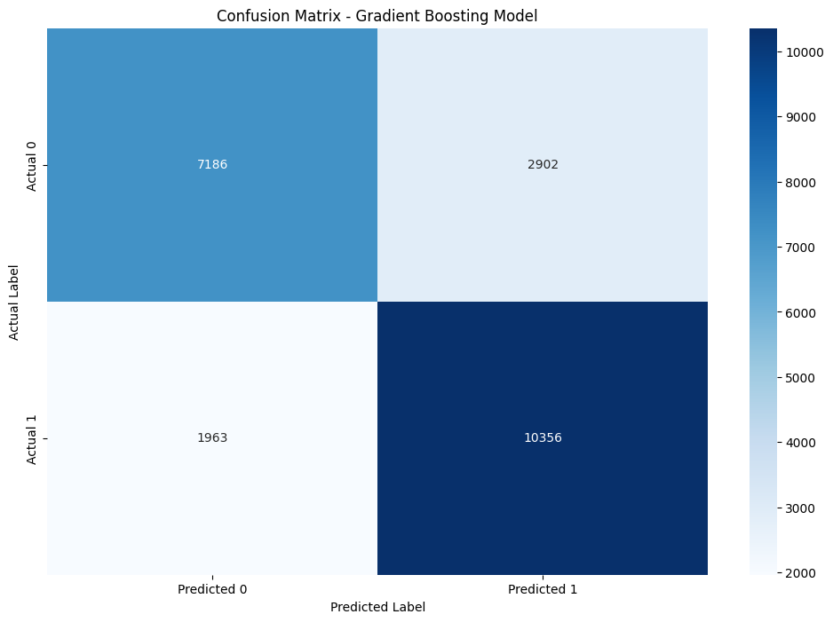

```
Confusion Matrix:
[[ 7186  2902]
 [ 1963 10356]]

Correct Predictions: 17542
Incorrect Predictions: 4865
Total Test Cases: 22407
Classification Report:
              precision    recall  f1-score   support

         0.0       0.79      0.71      0.75     10088
         1.0       0.78      0.84      0.81     12319

    accuracy                           0.78     22407
   macro avg       0.78      0.78      0.78     22407
weighted avg       0.78      0.78      0.78     22407
```

```python
import matplotlib.pyplot as plt
import seaborn as sns
from sklearn.metrics import confusion_matrix, classification_report

gb_predictions = best_gb_model.predict(X_test)
cm = confusion_matrix(y_test, gb_predictions)


plt.figure(figsize=(12, 8))
sns.heatmap(cm, annot=True, fmt='d', cmap='Blues',
            xticklabels=['Predicted 0', 'Predicted 1'],
            yticklabels=['Actual 0', 'Actual 1'])
plt.title('Confusion Matrix - Gradient Boosting Model')
plt.ylabel('Actual Label')
plt.xlabel('Predicted Label')
plt.show()

print("Confusion Matrix:")
print(cm)
print(f"\nCorrect Predictions: {cm[0,0] + cm[1,1]}")
print(f"Incorrect Predictions: {cm[0,1] + cm[1,0]}")
print(f"Total Test Cases: {cm.sum()}")

print("Classification Report:")
print(classification_report(y_test, gb_predictions))
```

```
Confusion Matrix Analysis
```

Looking at my confusion matrix results, I'm happy with how the Gradient Boosting model performed. Getting 78% accuracy means my model is correctly predicting about 4 out of 5 cases, which seems solid for this dataset.

What I find promising is that the model performs pretty similarly on both classes. Class 1 (home team won) actually does slightly better with 84% recall and 81% F1-score, while Class 0 (home team lost) gets 71% recall and 75% F1-score. The precision is nearly identical at around 78-79% for both classes, which tells me the model isn't heavily biased toward predicting one class over the other.

```
ROC Curve
```

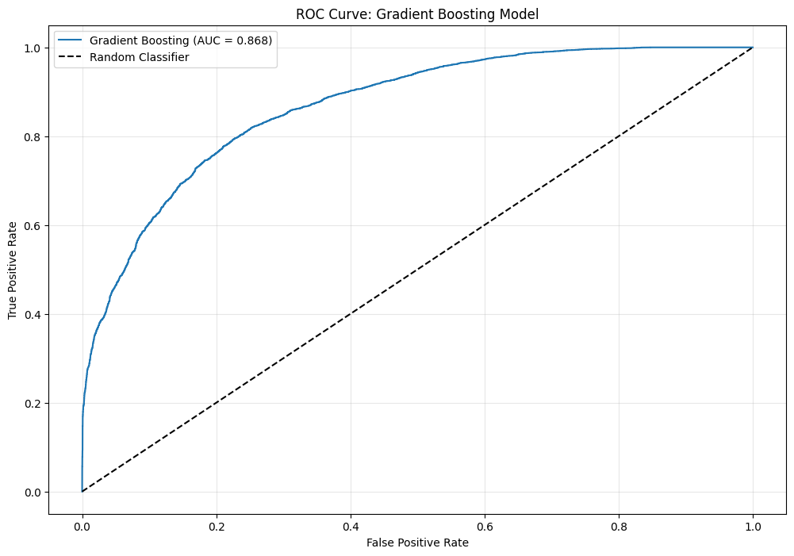

```python
gb_probs = best_gb_model.predict_proba(X_test)[:, 1]

fpr, tpr, thresholds = roc_curve(y_test, gb_probs)
auc_score = roc_auc_score(y_test, gb_probs)


plt.figure(figsize=(12, 8))
plt.plot(fpr, tpr, label=f'Gradient Boosting (AUC = {auc_score:.3f})')
plt.plot([0, 1], [0, 1], 'k--', label='Random Classifier')
plt.xlabel('False Positive Rate')
plt.ylabel('True Positive Rate')
plt.title('ROC Curve: Gradient Boosting Model')
plt.legend()
plt.grid(True, alpha=0.3)
plt.show()
```

```
ROC Curve Analysis
```

The blue curve is clearly way above the diagonal dashed line, which shows my model is doing much better than just random guessing. What I find most encouraging is how steep the curve rises on the left side, this means I can get a high true positive rate while keeping the false positive rate low, which is exactly what you want. The curve shows that at low false positive rates (say around 10-20%), I'm already catching about 60-75% of the true positives, which is pretty good performance. The AUC of 0.868 confirms what I saw in my other metrics, this model has strong discriminative ability. An AUC close to 0.9 is considered really good, so 0.868 tells me the model learned meaningful patterns from my data rather than just memorizing noise.

## 16. Conclusion

After fitting and tuning several machine learning models, including logistic regression, random forest, gradient boosting, and support vector machines, I found that all models performed similarly well, with gradient boosting achieving the highest ROC AUC. The results suggest that the features engineered from in-game statistics are highly predictive of game outcomes, and that even relatively simple models can perform well with well-prepared data. Looking ahead, future work could explore more granular play-by-play data, incorporate player-level statistics, or apply these models to live win probability tracking during games. Overall, this project demonstrates the power of data-driven approaches in understanding and predicting the ebb and flow of NBA games.

While my models achieved impressively high accuracy and ROC AUC scores, I realized that these metrics are heavily influenced by the many “easy” snapshots in the dataset, such as late-game situations where the outcome is nearly certain due to a large lead. In reality, predicting the winner early in the game or when the score is close is much more challenging, and the model’s performance in those scenarios is likely lower than the overall metrics suggest.